# Rendu 1

DODZRO Darryl Junior Koffi, FOTIO NGNINLAJUNG Francky, HU Xinyu, NOUGWA KEMAJOU Tatiana

2026-04-20

# Introduction

## 1. Données

Le jeu de données étudié porte sur les matchs de Premier League anglaise et couvre plusieurs saisons (de 1993 à 2022). Il est fourni au format **CSV** et contient **11 113 observations** (matchs) et **23 variables**.

Chaque observation correspond à un match et regroupe des informations détaillées sur :

- **L’identité du match** : Saison, date, équipes à domicile (`HomeTeam`) et à l’extérieur (`AwayTeam`).
- **Les scores** : Buts à la mi-temps (`HTHG`, `HTAG`) et au coup de sifflet final (`FTHG`, `FTAG`).
- **Les statistiques de jeu** : Nombre de tirs (`HS`, `AS`), tirs cadrés (`HST`, `AST`), fautes commises (`HF`, `AF`), corners (`HC`, `AC`) et l’identité de l’arbitre (`Referee`).
- **La discipline** : Cartons jaunes (`HY`, `AY`) et cartons rouges (`HR`, `AR`).

Le dataset est structuré de manière à permettre une analyse comparative entre les performances à domicile et à l’extérieur, ainsi qu’une étude de l’évolution des statistiques de jeu sur près de trois décennies.

## 2. Plan d’analyse

Notre démarche d’analyse suit le cycle **Aquire > Filter > Mine > Refine** afin de transformer les données brutes en informations exploitables :

1. **Aquire & Filter (Traitement avec dplyr)** : Nettoyage des données, gestion des valeurs manquantes (`NA`) et création de variables calculées (comme le total de buts ou le cumul des cartons) pour garantir la fiabilité des analyses.
2. **Mine (Exploration statique avec ggplot2)** : Répondre à des questions ciblées pour valider nos premières hypothèses. Nous prévoyons d’explorer :
   - **La performance** : Existe-t-il un avantage réel à jouer à domicile ? Quelles sont les équipes les plus prolifiques ?
   - **La discipline** : Existe-t-il une corrélation entre les fautes et les cartons ? Les arbitres influencent-ils la sévérité du jeu ?
   - **La prédiction** : Le score à la mi-temps permet-il d’anticiper avec fiabilité le résultat final ?
3. **Refine (Interactivité avec Shiny)** : Transformer ces visualisations en outils interactifs pour permettre à l’utilisateur de filtrer les résultats par saison ou par équipe, offrant ainsi une vision plus granulaire des données.

Nous porterons une attention particulière au **Data-to-Ink ratio** et au **Lie Factor** (concepts vus en cours) pour garantir que nos graphiques sont à la fois lisibles et honnêtes.

# Exploration des données

## 2. Existe-t-il un avantage du terrain ?

### Hypothèse

Nous cherchons ici à savoir si le fait de jouer à domicile augmente les chances de victoire d’une équipe.

### Choix de la visualisation

La variable utilisée est `FTR` (*Full Time Result*), qui indique le résultat final du match : - `H` : victoire de l’équipe à domicile - `D` : match nul - `A` : victoire de l’équipe à l’extérieur

Pour répondre à cette question, nous utilisons un diagramme en barres, car cette visualisation permet de comparer simplement les effectifs ou les proportions entre plusieurs catégories.

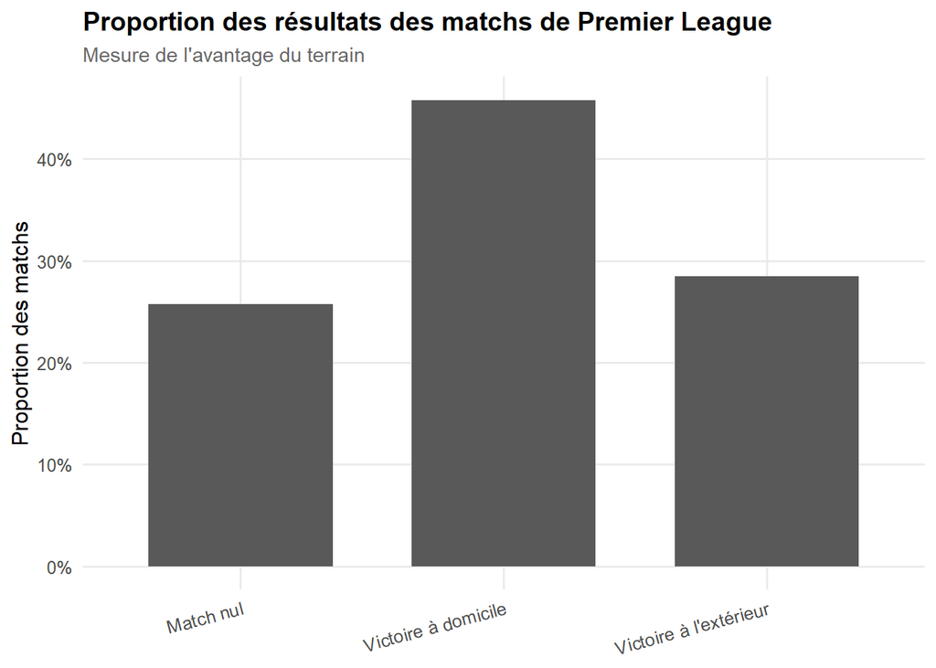

```r
# On compte le nombre de matchs pour chaque résultat final,
# puis on calcule leur proportion sur l'ensemble des matchs

home_adv <- epl %>%
  count(FTR) %>%
  mutate(
    proportion = n / sum(n),
    Resultat = recode(
      FTR,
      "H" = "Victoire à domicile",
      "D" = "Match nul",
      "A" = "Victoire à l'extérieur"
    )
  )

# Diagramme en barres des proportions de résultats
ggplot(home_adv, aes(x = Resultat, y = proportion)) +
  geom_col(width = 0.7) +
  scale_y_continuous(labels = scales::percent_format(accuracy = 1)) +
  labs(
    title = "Proportion des résultats des matchs de Premier League",
    subtitle = "Mesure de l'avantage du terrain",
    x = NULL,
    y = "Proportion des matchs"
  ) +
  theme_minimal(base_size = 12) +
  theme(
    plot.title = element_text(face = "bold", size = 14),
    plot.subtitle = element_text(size = 11, color = "grey40"),
    axis.text.x = element_text(angle = 15, hjust = 1),
    panel.grid.minor = element_blank()
  )
```

Cette différence met clairement en évidence l’existence d’un avantage du terrain. Le fait de jouer à domicile semble offrir un contexte plus favorable à la performance, ce qui augmente les chances de victoire de l’équipe qui reçoit.

Plusieurs facteurs peuvent expliquer cet avantage : le soutien du public, la familiarité avec le stade, l’absence de déplacement et, éventuellement, une pression supplémentaire exercée sur l’équipe visiteuse.

### Critique et limites

Il convient toutefois de rester prudent dans l’interprétation. Cette visualisation montre une tendance générale, mais elle ne permet pas, à elle seule, d’identifier précisément les causes de cet avantage. D’autres variables, comme la qualité relative des équipes ou l’évolution selon les saisons, pourraient également influencer ce résultat.

En conclusion, les données confirment bien l’existence d’un avantage du terrain en Premier League, puisque les équipes à domicile gagnent plus souvent que les équipes à l’extérieur.

## 3. Quelle est la distribution du nombre de buts par match ?

### Hypothèse

Nous cherchons à comprendre comment se distribue le nombre total de buts marqués par match en Premier League.  
On peut supposer que la majorité des matchs comportent un nombre modéré de buts, avec peu de rencontres très riches en buts.

### Visualisation

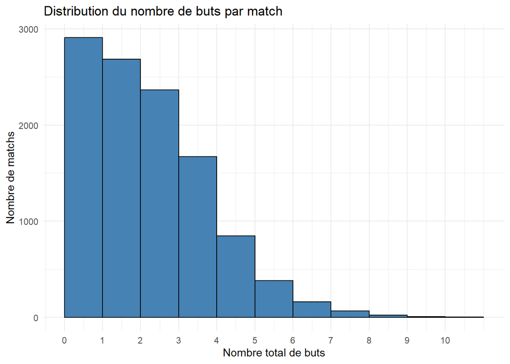

```r
library(dplyr)
library(ggplot2)
library(readr)

epl <- read_csv("../data/results.csv") %>%

# Création de la variable TotalGoals
  mutate(TotalGoals = FTHG + FTAG)
# Histogramme
ggplot(epl, aes(x = TotalGoals)) +
  geom_histogram(
    binwidth = 1,
    fill = "steelblue",
    color = "black",
    boundary = 0
  ) +
  scale_x_continuous(breaks = seq(0, 10, 1)) +
  labs(
    title = "Distribution du nombre de buts par match",
    x = "Nombre total de buts",
    y = "Nombre de matchs"
  ) +

  theme_minimal()
```

### Interprétation

L’histogramme montre que la majorité des matchs se concentrent entre 1 et 3 buts.

On observe une diminution progressive du nombre de matchs lorsque le nombre total de buts augmente, ce qui indique que les rencontres très riches en buts restent rares.

La distribution est asymétrique à droite, avec quelques valeurs élevées mais peu fréquentes.

Ainsi, le graphique confirme notre hypothèse initiale : les matchs de Premier League présentent généralement un nombre modéré de buts.

## 4. Quelles équipes marquent le plus de buts ?

### Hypothèse

Nous supposons que les équipes historiques du “Big Six” : *Arsenal, Chelsea, Liverpool, Manchester City, Manchester United, Tottenham Hotspur* dominent largement ce classement.

### Choix de la visualisation

Pour comparer des catégories : noms des équipes en fonction d’une valeur numérique : total de buts, le diagramme en barres horizontales est la solution la plus adaptée pour les raisons suivantes :

- **Lisibilité** : compte tenu du grand nombre d’équipes en Premier League, les noms seraient illisibles ou se chevaucheraient sur un axe horizontal (X) alors que l’orientation horizontale permet une lecture naturelle des noms de gauche à droite.
- **Optimisation du tri** : les barres sont triées de la plus grande à la plus petite et selon les principes du cours, un graphique trié réduit la charge cognitive du lecteur en lui permettant d’identifier immédiatement la hiérarchie et les extrêmes.
- **Comparaison directe** : cette représentation facilite la comparaison visuelle des longueurs de barres, mettant en évidence l’écart entre les leaders et le reste du classement.

```r
# Préparation des données : cumuler buts à domicile et à l'extérieur par équipe
home_goals <- epl %>%
  group_by(HomeTeam) %>%
  summarise(TotalHomeGoals = sum(FTHG, na.rm = TRUE)) %>%
  rename(Team = HomeTeam)

away_goals <- epl %>%
  group_by(AwayTeam) %>%
  summarise(TotalAwayGoals = sum(FTAG, na.rm = TRUE)) %>%
  rename(Team = AwayTeam)
```

```r
# Fusion et calcul du total
top_teams <- full_join(home_goals, away_goals, by = "Team") %>%
  mutate(GrandTotal = TotalHomeGoals + TotalAwayGoals) %>%
  slice_max(GrandTotal, n = 15)
```

On se limite au top 15 pour une meilleure lisibilité.

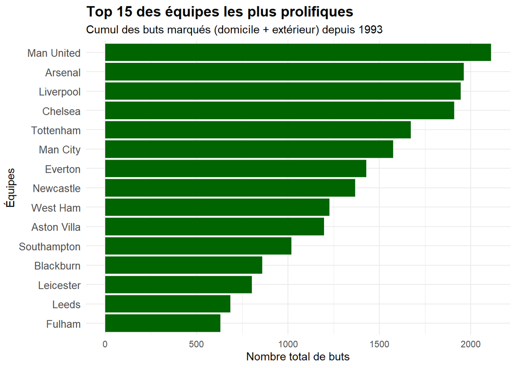

```r
ggplot(top_teams, aes(x = reorder(Team, GrandTotal), y = GrandTotal)) +
  geom_col(fill = "darkgreen") +
  coord_flip() +
  labs(
    title = "Top 15 des équipes les plus prolifiques",
    subtitle = "Cumul des buts marqués (domicile + extérieur) depuis 1993",
    x = "Équipes",
    y = "Nombre total de buts"
  ) +
  theme_minimal() +
  theme(
    plot.title = element_text(face = "bold", size = 14),
    axis.text.y = element_text(size = 10)
  )
```

### Analyse des résultats

Le graphique confirme la domination des clubs du “*Big Six*”. Manchester United, Arsenal et Liverpool occupent les trois premières marches du podium.

On observe un écrat marqué entre ces leaders historiques et le reste des équipes : seules les équipes de ce haut de tableau ont inscrits un nombre de buts suprieur à 1500 buts sur la période. Cette visualisation met en évidence une hiérarchie offensive très stable sur le long terme dans le championnat anglais.

### Critique et limites

Bien que ce graphique offre une vision globale efficace, il comporte certains biais qu’il est nécessaire de souligner :

- **Biais de longévité** : en utilisant le cumul historique des buts, nous favorisons les équipes n’ayant jamais été reléguées; une équipe très offensive présente seulement 2 ou 3 saisons en Premier League paraîtra moins “prolifique” qu’une équipe moyenne présente depuis 30 ans.
- **Normalisation (Lie Factor)** : pour une analyse plus “honnête” statistiquement, il serait pertinent de comparer ces données avec la moyenne de buts par match. Cela permettrait de minimiser l’effet du temps et d’identifier les équipes réellement qui sont à craindre devant le but.
- **Respect du Data-to-Ink ratio** : nous avons choisi un diagramme à barres horizontales pour garantir la lisibilité des noms de clubs; l’utilisation d’une couleur unique *vert foncé* sans gradients pour ne pas distraire l’œil des valeurs réelles
- **Absence de dynamique temporelle** : le graphique fige une période de 30 ans en une seule barre mais ne permet pas de voir si une équipe est en déclin offensif ou en pleine ascension sur les dernières saisons.

## 5. Les matchs sont-ils souvent décidés en seconde mi-temps ?

Il s’agit ici de comprendre la dynamique temporelle. Nous imaginons que La seconde mi-temps est plus décisive que la première, car les équipes s’adaptent tactiquement, la fatigue apparaît et les changements de joueurs influencent le jeu.

On s’attend donc à observer :

- Davantage de buts en seconde mi-temps
- De potentiellement des changements de résultat après la mi-temps.

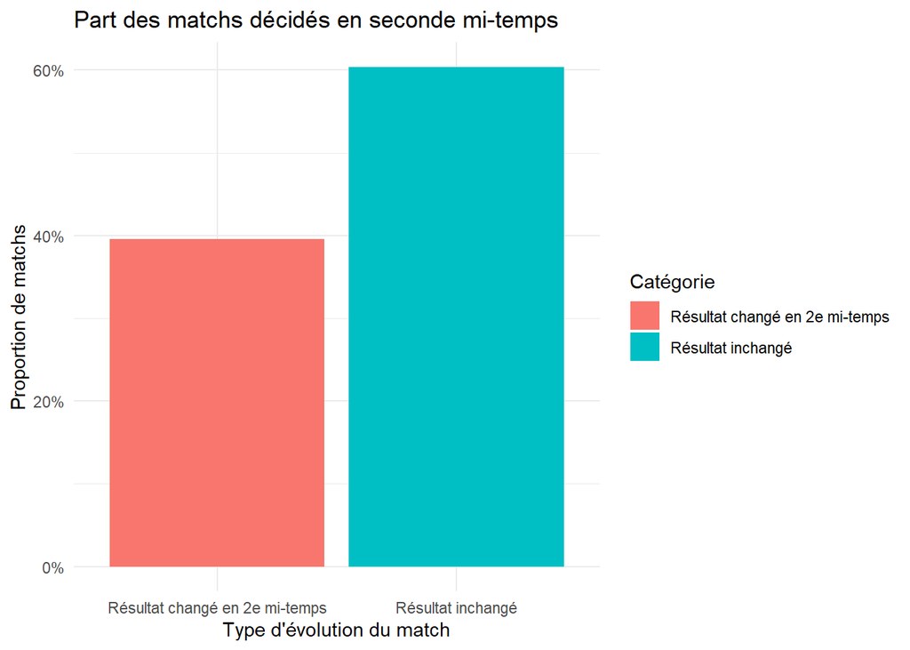

```r
# Import des librairies

library(ggplot2)
library(dplyr)

# Lecture du dataset


# Nettoyage de données

epl_clean <- epl %>%
  filter(!is.na(HTR), !is.na(FTR))

# Préparation de données

epl_clean <- epl_clean %>%
  mutate(
    Decision = ifelse(HTR == FTR,
                      "Résultat inchangé",
                      "Résultat changé en 2e mi-temps")
  )

# Visualisation

epl_clean %>%
  count(Decision) %>%
  mutate(prop = n / sum(n)) %>%
  ggplot(aes(x = Decision, y = prop,fill = Decision)) +
  geom_bar(stat = "identity") +
  labs(
    title = "Part des matchs décidés en seconde mi-temps",
    x = "Type d'évolution du match",
    y = "Proportion de matchs",
    fill = "Catégorie"
  ) +
  scale_y_continuous(labels = scales::percent) +

  theme_minimal()
```

## Interprétation

Ce graphique présente la répartition des matchs selon l’évolution du résultat entre la mi-temps et la fin du match on observe donc :

environ ~61 % de résultat inchangé et ~39 % de Résultat changé en seconde mi-temps.

Cela nous permet de répondre à la question posée en disant que,les matchs ne sont pas majoritairement décidés en seconde mi-temps, mais ont une proportion significative.

L’hypothèse du début n’est donc pas vérifiée

Le fait que plus de la moitié des matchs gardent le même résultat suggère que la première mi-temps joue déjà un rôle déterminant dans l’issue du match. Une équipe qui mène à la pause a donc de fortes chances de conserver son avantage.

## Limite

Même si le résultat ne change pas (HTR = FTR), cela ne signifie pas que :la seconde mi-temps n’a pas été importante

Par exemple : si on a un score de 0-0 à la mi-temps et 2-2 à la fin,on voit que le résultat ne change pas (toujours un match nul), mais match très actif en seconde période.

Donc cette analyse capture les changements d’issue, mais pas la dynamique réelle du match.

[output not shown]

## Question 20 — Le nombre de buts évolue-t-il selon les saisons ?

### Hypothèse

Nous cherchons à savoir si le nombre moyen de buts marqués par match évolue au fil des saisons de Premier League.

On peut supposer que certaines saisons sont plus offensives que d’autres, ce qui pourrait se traduire par des variations du nombre moyen de buts.

### Visualisation

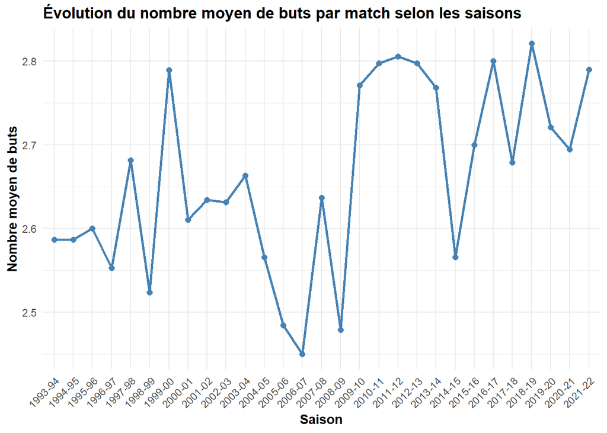

```r
library(dplyr)
library(ggplot2)
library(readr)

# On ajoute une variable représentant le total de buts par match
epl <- read_csv("../data/results.csv") %>%
  mutate(TotalGoals = FTHG + FTAG)
# Calcul de la moyenne de buts par saison
season_goals <- epl %>%
  filter(!is.na(Season), !is.na(TotalGoals)) %>%
  group_by(Season) %>%
  summarise(MeanGoals = mean(TotalGoals), .groups = "drop")

# Courbe d'évolution du nombre moyen de buts par saison
ggplot(season_goals, aes(x = Season, y = MeanGoals, group = 1)) +
  geom_line(color = "steelblue", linewidth = 1) +
  geom_point(color = "steelblue", size = 2) +
  labs(
    title = "Évolution du nombre moyen de buts par match selon les saisons",
    x = "Saison",
    y = "Nombre moyen de buts"
  ) +
  theme_minimal() +
  theme(
    plot.title = element_text(face = "bold"),
    axis.title = element_text(face = "bold"),
    axis.text.x = element_text(angle = 45, hjust = 1)
  )
```

### Interprétation

Le graphique montre l’évolution du nombre moyen de buts par match au fil des saisons de Premier League.

On observe que cette moyenne reste relativement stable, généralement comprise entre 2.5 et 2.8 buts par match. Cela signifie que les rencontres comportent en moyenne entre 2 et 3 buts, ce qui traduit un bon équilibre entre phases offensives et défensives dans le championnat.

Cependant, on remarque certaines fluctuations selon les saisons. Par exemple, une baisse notable autour des saisons 2005–2008 suggère une période plus défensive, tandis qu’une augmentation après 2010 indique un jeu plus offensif, avec davantage d’occasions et de buts marqués.

Depuis les années récentes, la moyenne tend légèrement à augmenter, ce qui peut s’expliquer par l’évolution du football moderne : intensité plus élevée, stratégies offensives plus développées et amélioration des performances des joueurs.

Ainsi, même si le nombre de buts reste globalement stable, on observe une légère tendance à l’augmentation, traduisant un championnat de plus en plus spectaculaire.